# *Pinus nigra* fertility

- A study was conducted to describe the reproductive biology of an invasive species (Pinus nigra) in a native forest in Argentina. For this, the number of pines (or cones) produced in one year by each P. nigra specimen in the study area was recorded.
- The age (by counting rings) and height (in meters) of each tree were also recorded.

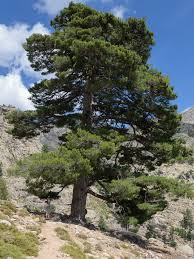

Pinus Nigra

```r
#Loading libraries
library(readxl)
library(carData)
library(ggplot2)
library(car)
library(MASS)
library(ggpubr)
library(equatiomatic)
library(knitr)
library(broom)
library(kableExtra)
```

# Exploratory Analysis

```r
#For model performance analysis
supuestosGLM <- function(modeloGLM) {

  ajust <- fitted(modeloGLM)
  rp <- resid(modeloGLM, type="pearson")
  datos_p_supuestos <-data.frame(cbind(rp, ajust))

  k1<- ggplot(data=datos_p_supuestos, aes(x=ajust, y=rp)) +
    geom_point()   +
    geom_jitter(width=0.1)+
  geom_line(y=2, linetype = "dashed", color="blue") +
  geom_line(y=-2, linetype = "dashed", color="blue")+
  ylab("RP (per observed data)") +
  xlab("Predicted (per model)") +
  labs(title = "RP vs predicted",
       caption = paste('.'))+
    theme_minimal()

  datos_dist_cook = data.frame(cooks.distance(modeloGLM))
  for (i in (1:nrow(datos_dist_cook))) {
    datos_dist_cook$identidad[i]<- i
  }
  names(datos_dist_cook)[1] <- "DCook"
  names(datos_dist_cook)[2] <- "Id"

  k2 <- ggplot(data=datos_dist_cook, aes(y=DCook, x=Id)) +
  geom_point()   +
  geom_line(y=1, linetype = "dashed", color="red", size =2) +
  labs(title = "Cook's Distance",
       caption = "...")+
     theme_minimal()

  graficos_supuestos = ggarrange(k1, k2, ncol=2, nrow=1)
  return (graficos_supuestos)
}
```

- First let’s inspect the data to explore how the number of cones are distributed as function of the tree’s age, incorporating also the tree’s height.

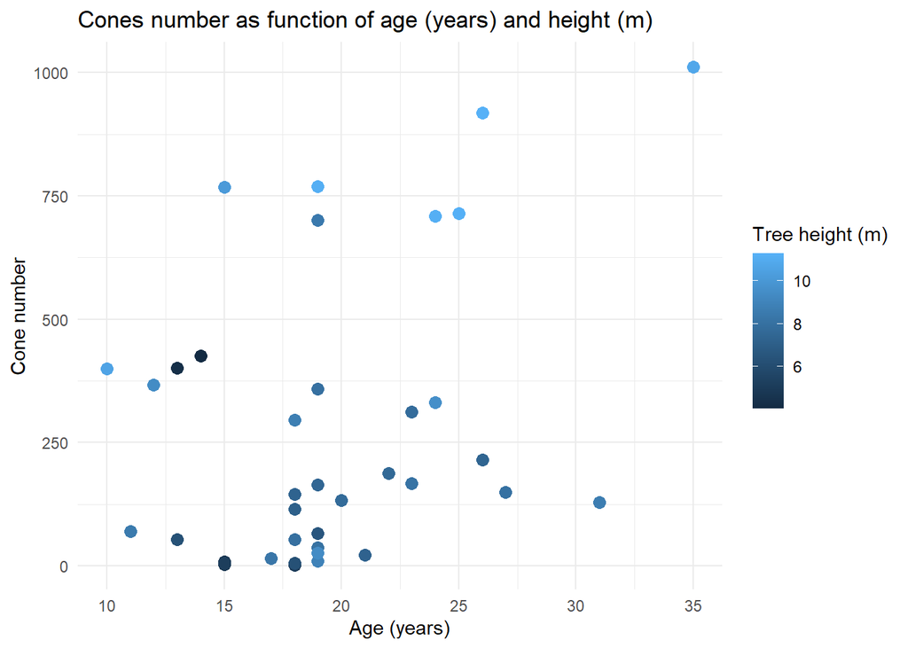

```r
ggplot(pines, aes(x = age_years, y = n_cones, color = height_m)) +
  geom_point(size=3) +
  labs(title = "Cones number as function of age (years) and height (m)",
       x = "Age (years)",
       y = "Cone number",
       color = "Tree height (m)") +
  theme_minimal()
```

# Statistical Modelling

### Poisson GLM

- Per the response variable’s nature, the first approach would be to use a Poisson GLM model.

```r
model_poi = glm(n_cones ~ age_years + height_m, family='poisson', data=pines)
```

- Now let’s see whether the model’s assumptions are met.

[figure not shown]

```r
model_poi_dispFact = sum(resid(model_poi , type="pearson")^2/model_poi $df.residual)
```

- Upon checking assumptions, we can observe there are extreme values for Pearson’s residues as well as leveraging datapoints per Cook’s distance.
- Also, there should not be any suspicion of sub/overdispersion and in fact, the overdispersion factor exceeds what’s allowed [Disp. factor = 250.8120843]. This could be due to a wide variety fo reasons including outliers, model’s subspecification or lack of independence between observations.

### Negative Binomial GLM

- One strategy to overcome overdispersion is to change the GLM distribution to Negative Binomial, which is useful for counting data with higher variance as expected per a Poisson GLM.

```r
model_bn = glm.nb(n_cones ~ age_years * height_m, data=pines, link = log)
additive_bn = glm.nb(n_cones ~ age_years + height_m, data=pines, link = log)
age_bn = glm.nb(n_cones ~ age_years , data=pines, link = log)
height_bn = glm.nb(n_cones ~ height_m, data=pines, link = log)
kable(AIC(model_bn, additive_bn, age_bn, height_bn))
```

|  | df | AIC |
| --- | --- | --- |
| model_bn | 5 | 492.3552 |
| additive_bn | 4 | 495.6084 |
| age_bn | 3 | 500.5751 |
| height_bn | 3 | 493.6191 |

```r
dispersion = sum(resid(model_bn, type="pearson")^2/(model_bn$df.residual+1))
dispersion
```

```
## [1] 0.7865709
```

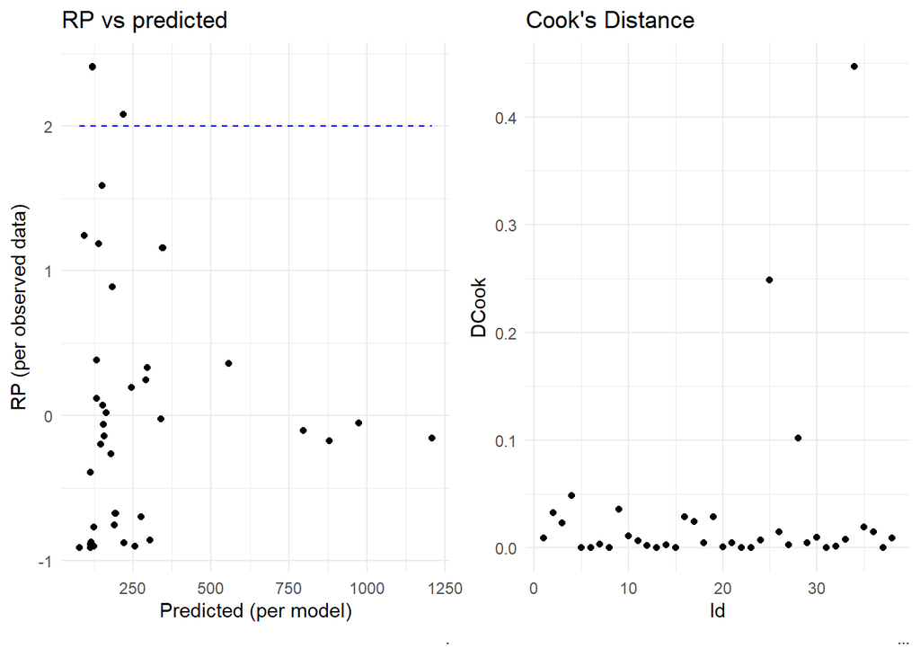

```r
sup_BN = supuestosGLM(model_bn)
sup_BN
```

- Within Binomial Negative we estimate one additional parameter, the aggregation factor (‘Theta’) which accounts for the expected higher variance.

### Model interpretation

- Model equation

```r
extract_eq(model_bn, greek_colors='blue', subscript_colors = 'blue')
```

$$\log ({ E( \operatorname{n_cones} ) }) = {\color{blue}{\alpha}} +
{\color{blue}{\beta}}_{{\color{blue}{1}}}(\operatorname{age\_years}) +
{\color{blue}{\beta}}_{{\color{blue}{2}}}(\operatorname{height\_m}) +
{\color{blue}{\beta}}_{{\color{blue}{3}}}(\operatorname{age\_years}
\times \operatorname{height\_m})$$

### Model’s results

```r
tidy_model_bn <- tidy(model_bn)

tidy_model_bn %>%
  kable("html", caption = "Summary of Negative Binomial Model ('model_bn')") %>%
  kable_styling(bootstrap_options = c("striped", "hover", "condensed"))
```

Summary of Negative Binomial Model (‘model_bn’)

| term | estimate | std.error | statistic | p.value |
| --- | --- | --- | --- | --- |
| (Intercept) | 8.8071549 | 2.9421500 | 2.993442 | 0.0027585 |
| age_years | -0.3357856 | 0.1696167 | -1.979673 | 0.0477403 |
| height_m | -0.3400203 | 0.3229791 | -1.052763 | 0.2924498 |
| age_years:height_m | 0.0362353 | 0.0179262 | 2.021366 | 0.0432419 |

### Per the summary we can get

- Significance of the interaction age x height, results must be analyzed considering this and not the variable’s simple effect: the number of cones depends on the joint effect of these variables.
- Estimated deviance (44.2187 %)
- Aggregation factor (Theta = 0.889)